# Stat0009 ICA3 (2021)

# Introduction

- Made available UCL Week 16
- Due UCL Week 24; 9 February 2022.
- You are to work in groups of 2-4; there should be no overlap with your ICA2 groups.
- This ICA consists of five questions, worth 65 points;
- another 10 points will be given based on presentation, so that the total available points is 75.
- This ICA is worth 30 percent of your grade for this module.
- Many questions will require you to write and run R/Python code.
- The ICA must be completed in R Markdown/Juptyer Notebook and typeset using Markdown with Latex code, just like the way our module content is generated. You can choose to use either R or Python.
- Please hand in the html file and the Rmd/ipynb source file.
- As usual, part of the grading will depend on the clarity and presentation of your solutions.
- You are to do this assignment by yourselves, without any help from others.
- You are allowed to use any materials and code that was presented so far.
- Do not search the internet for answers to the ICA.
- Do not use any fancy code or packages imported from elsewhere.

## Plagiarism and collusion

Please familarize yourself with [the following excerpt on plagiarism and collusion from the student handbook](https://tsoo-math.github.io/ucl/Plagiarism-Collusion.pdf)

By ticking the submission declaration box in Moodle you are agreeing to the following declaration:

**Declaration:** I am aware of the UCL Statistical Science Department’s regulations on plagiarism for assessed coursework. I have read the guidelines in the student handbook and understand what constitutes plagiarism. I hereby affirm that the work I am submitting for this in-course assessment is entirely my own.

## Anonymous Marking

Please do **not** write your name anywhere on the submission. Please include only your **student number** as the proxy identifier.

# Questions

## 1.) [10 points] Apery’s constant

- [2 points] Prove (using calculus) that

$$\zeta(3) = \sum_{n=1} ^{\infty} \frac{1}{n^3} < \infty.$$

- [6 points] Consider the probability distribution $\mu$, where
  $$\mu(n) = \frac{1}{\zeta(3)n^3}.$$
  Use the Metropolis algorithm to sample from $\mu$, so that you do not need to know the value of $\zeta(3)$.
- [2 points] Now that you can sample from $\mu$, use simulations to estimate the value of $\zeta(3)$.

### Solution

- The easiest way is to probably invoke the integral test.
- To run the Metropolis algorithm, we modify the code from [a previous in-class session](https://tsoo-math.github.io/ucl2/class4-sol.html). We use

$$Q(j|i) = Q_{ij} = \tfrac{1}{2} \text{ if and only if } |i-j|=1.$$

This allows to sample from $\mu$, and thus estimate $\mu(1)$, and also $\zeta(3)$.

```r
h <- function(x){
 z=0
  if(x >0 ) {z = 1/(x^3)   }
 z
  }


Yq <- function(x){
   y= x+ 2*rbinom(1,1,1/2) -1
y
}

a <- function(j,i){
m=min( c( h(j)/h(i), 1 ))
m
}

metro <- function(n){
  x=1
  for(k in 1:n){
    i = x[length(x)]
    j = Yq(i)
    p = a(j,i)
    x = c(x,i)
      if ( rbinom(1,1,p)==1 ) {
      x[length(x)] <- j
            }
  }
  x
}

x= replicate(2000, metro(200)[length(metro(200))])
1/mean(x==1)
```

```
## [1] 1.181335
```

## 2.) [15 points] Bayesian statistics and MCMC

We say that a positive continuous random variable $X$ has the **inverse gamma** distribution with parameters $\alpha >0$ and $\beta >0$ if it has pdf given by
$$(y; \alpha, \beta) \mapsto \frac{\beta^{\alpha}}{\Gamma(\alpha)} y^{-\alpha -1} e^{\tfrac{-\beta}{y}} \mathbf{1}[y >0],$$
where $\Gamma$ is the usual Gamma function.

We say that a positive continuous random variable $W$ has the **Scaled-Weibull distribution** with shape parameter $k$ and scale parameter $\theta >0$ if it has pdf given by
$$(w_1; k,\theta) \mapsto \mathbf{1}[w_1 >0]\frac{k w_1^{k-1}}{\theta} \exp[ - \tfrac{w_1^{k}}{\theta } ] .$$

- [2 points] Let ${W} = (W_1, \ldots, W_n)$ be a random sample from the Scaled-Weibull distribution with known shape parameter $k$ and unknown scale parameter $\theta >0$. Show that $t({W}) := \sum_{i=1} ^n W_i ^k$ is a sufficient statistic for $\theta$.
- [3 points] Fix $k >0$. Let ${X} = (X_1, \ldots, X_n)$ be a random sample where the conditional distribution of $X_1$ given $\Theta = \theta$ has the Scaled-Weibull distribution with shape parameter $k$ and scale parameter $\theta$, and $\Theta$ has the inverse gamma distribution with parameters $\alpha$ and $\beta$. Given sample data $x=(x_1, x_2, \ldots, x_n)$. Compute the posterior distribution $s(\theta|t(x))$ up to constant factors.
- [3 points] Identify the distribution of $s(\theta|t(x))$.
- [4 points] Now *pretend* you could not identify it, and could not deduce exact constant factors. For the simple case, where $\alpha =2$, $\beta=3$, $n=3$, and $x_1=2, x_2=4, x_3=6$, sample from $s(\theta|t(x))$ using the Metropolis algorithm.
- [3 points] Plot independent samples in a probability histogram and compare with the true result.

### Solution

- We have that

$$\begin{eqnarray*}
L({w}; \theta ) &=& \prod_{i=1}^n \frac{k w_i^{k-1}}{\theta} \exp[ - \tfrac{w_i^{k}}{\theta}] \\
&=& \big( \prod_{i=1} ^n kw_i^{k-1} \big) \cdot \big( \frac{1}{\theta^{n}}\exp( -t / \theta) \big),
\end{eqnarray*}$$

from which the result follows from the Neyman factorization theorem, where we set
$$H({w}) :=\big( \prod_{i=1} ^n kw_i^{k-1} \big)$$
and

$$g(t; \theta) := \frac{1} {\theta^{n}}\exp( -t / \theta).$$

- Let $r(\theta)$ be the prior distribution and $s(\theta | {x})$ denote the posterior. From the previous part, given $\Theta= \theta$, we know that $t({X})$ is a sufficient statistic for $\theta$, thus it suffices to compute $s(\theta | t)$. We have, using the notation from the previous part that

$$\begin{eqnarray*}
s(\theta | t) &\propto& g(t; \theta) r(\theta)\\
&\propto& \frac{1}{\theta^{n}}\exp( -t / \theta) \cdot \frac{\beta^{\alpha}}{\Gamma(\alpha)} \theta^{-\alpha -1} e^{\tfrac{-\beta}{\theta}} \\
&\propto& \theta^{ -n - \alpha -1 } \exp(-(t+ \beta)/\theta ).
\end{eqnarray*}$$

- We recognize that $s(\theta|t)$ is the inverse gamma distribution with hyperparameters $\alpha':= n + \alpha$ and $\beta':= \beta + t$.
- To run the Metropolis algorithm, we modify the code from [a previous in-class session](https://tsoo-math.github.io/ucl2/class4-sol.html)

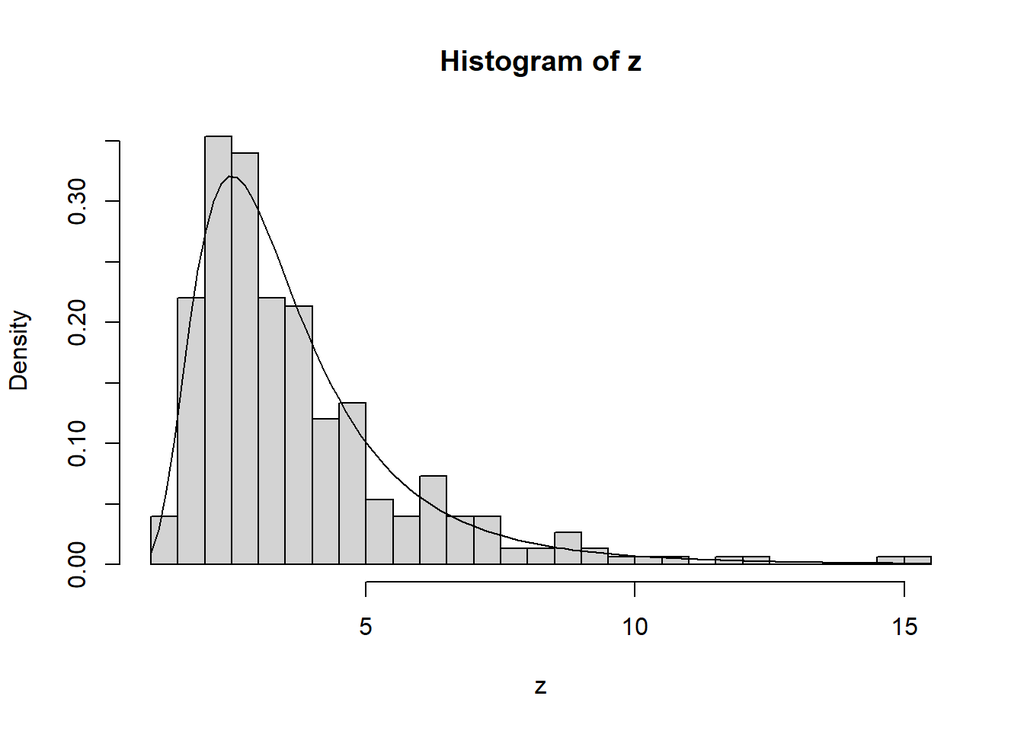

```r
h <- function(x){
 z=0
  if(x >0 ) {z= (x^{-3-2-1}) *exp(-(12+3)/x)   }
 z
  }


Yq <- function(x){
   y= rnorm(1,x,1)
y
}

a <- function(j,i){
m=min( c( h(j)/h(i), 1 ))
m
}

metro <- function(n){
  x=0.5
  for(k in 1:n){
    i = x[length(x)]
    j = Yq(i)
    p = a(j,i)
    x = c(x,i)
      if ( rbinom(1,1,p)==1 ) {
      x[length(x)] <- j
            }
  }
  x
}

library(invgamma)



z = replicate(300, metro(5000)[length(metro(5000))])

hist(z, prob=TRUE, breaks=35)
x= seq(0.1, 20, by =0.2)
curve(dinvgamma(x,shape=5,rate=15), add=TRUE)
```

## 3.) [15 points] A Poisson process process on a perimeter of a semi-circle

Let $\Gamma$ be a homogeneous Poisson point process of intensity $2$ on the upper half of the circle given by $x^2+y^2 =1$. Here, $\Gamma$ is not the Gamma function. Consider the point process $\Upsilon$ given by the projection of $\Gamma$ onto the $x$-axis; that is, if $\Gamma$ had $n$ points and they are given by $(x_1, y_1), \ldots, (x_n, y_n)$, then the points of $\Upsilon$ are just the $x$-coordinates $x_1, \ldots, x_n$.

- [5 points] Write code to simulate $\Gamma$ and $\Upsilon$. Graphically display a sample realization of these point processes.
- [5 points] Demonstrate using simulations that $\Upsilon$ is *not* a homogeneous Poisson point process on $[-1,1]$.
- [5 points] Show analytically that $\Upsilon$ cannot be a homogeneous Poisson point process on $[-1,1]$.

### Solutions

- We note that the problem is easier in polar coordinates. In order to simulate a uniform point on the semi-circle, it suffices to generate a uniform angle $\Theta$ on $[0, \pi]$, and then consider the point $(r=1, \Theta)$.

```r
arc <- function(){
  N = rpois(1,2*pi)
  points = NULL
  if (N >0){
    angles = pi*runif(N)
    points = cbind(cos(angles), sin(angles))
}
    points
  }

a=arc()
x =a[,1]
y =a[,2]
n = length(y)
zeros = rep(0, n)
x = c(x, x)
y = c(y, zeros)

aa = cbind(x,y)


aa
```

```
##                 x            y
##  [1,]  0.68082051 7.324503e-01
##  [2,] -0.14791807 9.889996e-01
##  [3,]  0.37798300 9.258125e-01
##  [4,] -0.20829296 9.780665e-01
##  [5,] -0.09655389 9.953278e-01
##  [6,]  0.56355025 8.260818e-01
##  [7,] -0.93003491 3.674712e-01
##  [8,] -1.00000000 8.059216e-05
##  [9,]  0.83526151 5.498529e-01
## [10,]  0.15742677 9.875307e-01
## [11,]  0.68082051 0.000000e+00
## [12,] -0.14791807 0.000000e+00
## [13,]  0.37798300 0.000000e+00
## [14,] -0.20829296 0.000000e+00
## [15,] -0.09655389 0.000000e+00
## [16,]  0.56355025 0.000000e+00
## [17,] -0.93003491 0.000000e+00
## [18,] -1.00000000 0.000000e+00
## [19,]  0.83526151 0.000000e+00
## [20,]  0.15742677 0.000000e+00
```

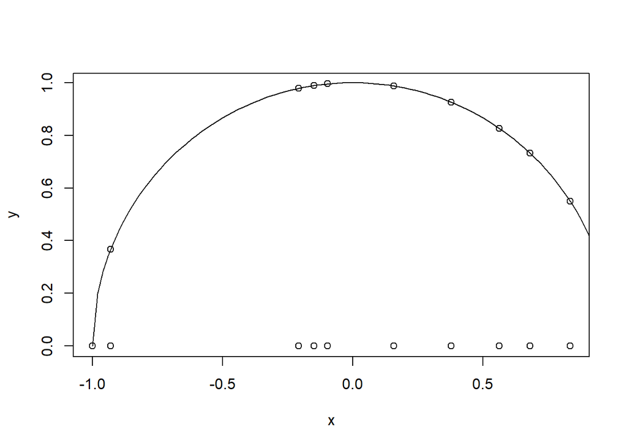

```r
plot(aa)
curve(sqrt(1-x^2), from=-1, to=1, add=TRUE)
```

- We will demonstrate that $\Upsilon$ likes to have points near the boundaries rather than the center.

```r
counts <-function(a,b){
  x = arc()[,1]
  s=sum(x > a & x <b)
s
}

s=replicate(100,counts(-1,-0.8))
t = replicate(100, counts(-0.1, 0.1))

mean(s)
```

```
## [1] 1.31
```

```r
mean(t)
```

```
## [1] 0.35
```

## 4.) [15 points] The transition rate matrix

You are given the the sample data from an irreducible continuous-time Markov chain. The sample data includes the jump times $(0,j_1, \ldots, j_n)$ and states $(s_0, s_1, \ldots, s_n)$; here at time $j_i$ the Markov chain jumps into state $s_i$ and stays there until the next jump which occurs at time $j_{i+1}$.

- [8 points] When $n$ is large, give a method for estimating the transition rate matrix, also referred to as the $Q$ matrix. Explain why your estimate is reasonable.
- [7 points] Import the data from the file Q.txt and use this data and your method above to estimate the $Q$ matrix.

## Solution

- Let $J$ be the jump chain. We can count the transitions

$$n_{ij} := \sum_{k=0} ^{n-1} \mathbf{1}[J_k=i, J_{k+1}=j],$$
and also let

$$n_i = \sum_{k=0} ^{n-1} \mathbf{1}[J_k=i].$$

Then by a version of the law of large numbers $n_{ij}/n_i \to m_{ij}$, so that we can recover the transition matrix corresponding to the jump chain.

- We can also estimate the holding times at each state in the following way: for each state $i$, let $H^i_k$ the time the Markov chain stays at state $i$, on its $k$-th visit; these are i.i.d. exponential random variables, and thus by the law of large numbers their mean goes to the corresponding mean holding time $h_i$

Thus with the relation $m_{ij}(h_i)^{-1} = q_{ij}$ we can estimate the $Q$ matrix; furthermore, we can also *force* the condition $-\hat{q}_{ii} := \sum_{j\not i} \hat{q}_{ij}$.

- The following code accomplishes the method outlined above.

```r
imported =read.table("Q.txt", sep=",")

states <- imported[,1]
times <- imported[,2]


m <- function(i,j){
  mij =NULL
for(k in 1:(length(states)-1)){
  if (states[k]==i & states[k+1] ==j ){
    mij = c(mij, k)
  }
}
mijp = length(mij)/sum(states==i)
mijp
}



tm <-function(i){
  mi = NULL
  timei=NULL
for(k in 1:length(states)){
  if (states[k]==i){
    mi = c(mi, k)}
}
for( k in 1: (length(mi)-1) ){
timei = c(timei, times[mi[k]+1] - times[mi[k]]  )
}
timei
  }

hi1 = 1/mean(tm(1))
hi2 = 1/mean(tm(2))
hi3 = 1/mean(tm(3))

Q <- matrix(c(-hi1,m(1,2)*hi1,m(1,3)*hi1, m(2,1)*hi2,-hi2,m(2,3)*hi2, m(3,1)*hi3, m(3,2)*hi3, -hi3), nrow =3)

Q = t(Q)
Q
```

```
##           [,1]      [,2]      [,3]
## [1,] -6.930188  3.952479  2.977709
## [2,]  1.971437 -2.958729  0.986977
## [3,]  1.938296  7.023883 -8.962179
```

## 5.) [10 points] Queues

Suppose you have Poisson arrivals, with intensity $6$. You are given the following two options. Option 1: we treat it like a $M(6)/M(8)/1$ system- the items are served by exponentially at rate $8$. Option 2: each item is painted red or blue independently with probability $\tfrac{1}{2}$; the coloured items report to different queues, with the red items are served exponentially at rate $4$, and the blue items served exponentially at rate $4$.

- [5 points] Run simulations to identify the stationary distributions of the items in each of the two options. Which option, on average, has more items in it?
- [5 points] Which option is better, from the items/customers perspective? Explain, analytically.

### Solutions

- In Option 2, by the colouring theorem, the coloured arrival processes are independent Poisson processes each with rate $3$, thus we are looking at two independent $M(3)/M(4)/1$ queues, compared to a single $M(6)/M(8)/1$ in Option 1. Suppose both options have been operating for a long time, so that they are both at stationarity, so there are a geometric number of items in each (coloured) queue. The total time an item spends in a $M(\lambda)/M(\mu)/1$ queue is exponential with parameter $\mu - \lambda$; we can also apply Little’s law ($L = \lambda W)$, since at stationarity, we know $L = \tfrac{\rho}{1-\rho}$, and obtain that total time has mean $\tfrac{1}{\mu - \lambda}$. In Option 1, an item spends on average $\tfrac{1}{2}$ units of time. In Option 2, regardless if you are coloured blue or red, you end up spending an average of $1$ unit time. Notice that if we applied Little’s law to Option 2, $L$ is the sum of two independent geometric random times, each with mean $\tfrac{3/4}{1-3/4} = 3$, thus there are on average $6$ blue or red items in the store, rather than the $3$ of Option 1. Option 1 is better.

# Endnotes

- Version: 16 December 2022
- [Rmd Source](https://tsoo-math.github.io/ucl2/2021-ica3-stat9-release.Rmd)